# Hands on 1

Natalia Acitores Rich (natsacitores@gmail.com)

Last update: 03 February, 2025

# Analysis of the Heart Disease Dataset

Load the data from [here](https://raw.githubusercontent.com/jpinero/DMI_2021/main/datasets/heart_disease_dataset.csv), and the description is [here](https://raw.githubusercontent.com/jpinero/DMI_2021/main/datasets/heart_disease_description.txt). The original dataset comes from [here](https://archive.ics.uci.edu/ml/datasets/Heart+Disease) and corresponds to the [processed cleveland data](https://archive.ics.uci.edu/ml/machine-learning-databases/heart-disease/processed.cleveland.data)

```r
## Libraries needed
library(ggplot2)
library(dplyr)
library(vcd)
heart_disease_dataset <- read.csv("data/heart_disease_dataset.csv", sep="")
```

## Perform an EDA on the dataset

#### General EDA

Number of individuals x Number of variables (features)

```r
# Number of variables
dim(heart_disease_dataset)
```

```
## [1] 303  15
```

```r
#Types of variables
str(heart_disease_dataset)
```

```
## 'data.frame':    303 obs. of  15 variables:
##  $ age       : int  63 67 67 37 41 56 62 57 63 53 ...
##  $ sex       : int  1 1 1 1 0 1 0 0 1 1 ...
##  $ cp        : int  1 4 4 3 2 2 4 4 4 4 ...
##  $ trestbps  : int  145 160 120 130 130 120 140 120 130 140 ...
##  $ chol      : int  233 286 229 250 204 236 268 354 254 203 ...
##  $ fbs       : int  1 0 0 0 0 0 0 0 0 1 ...
##  $ restecg   : int  2 2 2 0 2 0 2 0 2 2 ...
##  $ thalach   : int  150 108 129 187 172 178 160 163 147 155 ...
##  $ exang     : int  0 1 1 0 0 0 0 1 0 1 ...
##  $ oldpeak   : num  2.3 1.5 2.6 3.5 1.4 0.8 3.6 0.6 1.4 3.1 ...
##  $ slope     : int  3 2 2 3 1 1 3 1 2 3 ...
##  $ ca        : chr  "0" "3" "2" "0" ...
##  $ thal      : chr  "6" "3" "7" "3" ...
##  $ num       : int  0 2 1 0 0 0 3 0 2 1 ...
##  $ patient_id: int  1 2 3 4 5 6 7 8 9 10 ...
```

### Diagnosis of Heart Disease (num)

It is integer valued from 0 (no presence) to 4. Experiments with the Cleveland database have concentrated on simply attempting to distinguish presence (values 1,2,3,4) from absence (value 0).

The diagnosis is based on the angiographic disease status.

- Value 0: < 50% diameter narrowing. Absence
- Value 1: > 50% diameter narrowing. Presence.
- Values 2-4: Presence.

```r
heart_disease_dataset$num <- factor(heart_disease_dataset$num,
                                        levels = c(0,1,2,3,4),
                                        labels = c("Absence", "Presence","Presence","Presence","Presence"))
table(heart_disease_dataset$num, useNA = "ifany")
```

```
##
##  Absence Presence
##      164      139
```

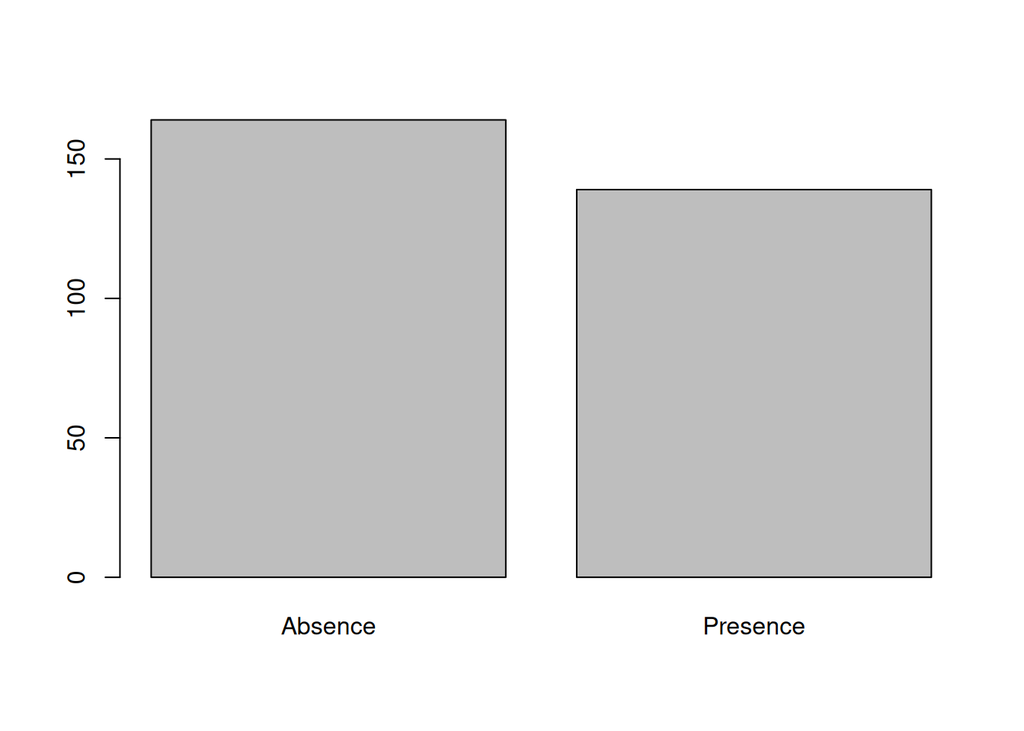

```r
barplot(table(heart_disease_dataset$num, useNA = "ifany"))
```

#### Analysis on Age

```r
# Check for missing values
sum(is.na(heart_disease_dataset$age))
```

```
## [1] 0
```

```r
summary(heart_disease_dataset$age)
```

```
##    Min. 1st Qu.  Median    Mean 3rd Qu.    Max.
##   29.00   48.00   56.00   54.44   61.00   77.00
```

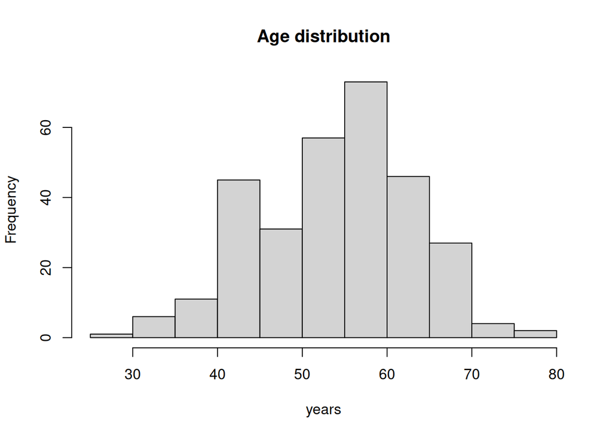

```r
#Visualize the variable to find outliers
hist(heart_disease_dataset$age, main = "Age distribution", xlab = "years")
```

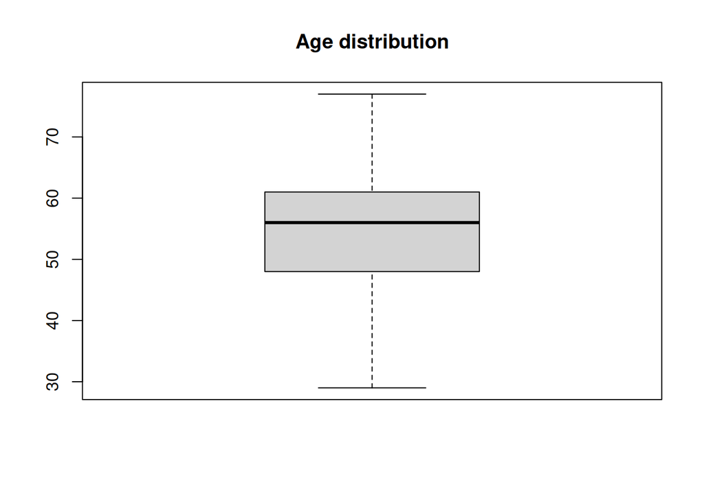

```r
boxplot(heart_disease_dataset$age, main="Age distribution")
```

When performing the analysis on age we are able to see that there are no missing values as the minimum age is 29.00 and the maximum is 77.00.

#### Analysis on sex

In the general EDA we saw that sex was accounted as a continuous variable, we changed the variable to be a factor to perform the correct analysis.

```r
# Looking for missing values
sum(is.na(heart_disease_dataset$sex))
```

```
## [1] 0
```

```r
#Change the values 0 = Female and 1 = Male
heart_disease_dataset$sex <- factor(heart_disease_dataset$sex,
                                    levels = c(1, 0),
                                    labels = c("Male", "Female"))
table(heart_disease_dataset$sex, useNA = "ifany")
```

```
##
##   Male Female
##    206     97
```

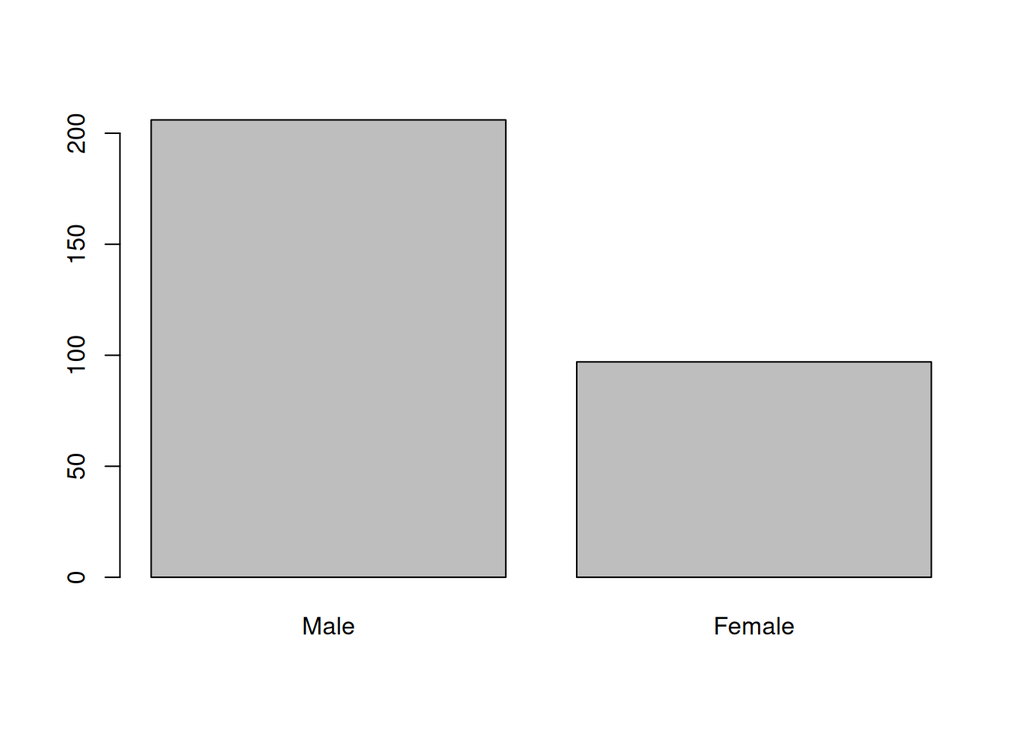

```r
barplot(table(heart_disease_dataset$sex, useNA = "ifany"))
```

In the analysis what we can see is that the study was not leveled, having more than double males than females.

### Analysis on Chest Pain (cp)

Chest pain type is represented as 1 = typical angina, 2 = atypical angina, 3 = non-anginal pain and 4 = asymptomatic. The numerical values were converted to categorical according to that representation.

```r
heart_disease_dataset$cp <- factor(heart_disease_dataset$cp,
                       levels = c(1, 2, 3, 4),
                       labels = c("Typical Angina", "Atypical Angina",
                                  "Non-Anginal Pain", "Asymptomatic"))
table(heart_disease_dataset$cp, useNA = "ifany")
```

```
##
##   Typical Angina  Atypical Angina Non-Anginal Pain     Asymptomatic
##               23               50               86              144
```

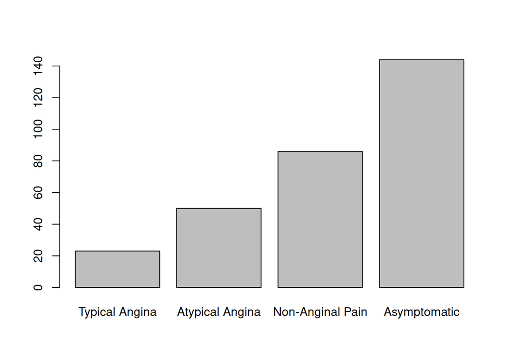

```r
barplot(table(heart_disease_dataset$cp, useNA = "ifany"))
```

Regarding the classification on chest pain, we can see how again it is not leveled having many more samples of asymptomatic and Non-anginal pain than of Typical Angina and Atypical Angina. This should be taken into account for further comparisons.

### Analysis on Resting Blood Pressure (trestbps)

```r
# Checking for NAs
table(is.na(heart_disease_dataset$trestbps)) #No NA's found
```

```
##
## FALSE
##   303
```

```r
# Analysis on the variable
summary(heart_disease_dataset$trestbps)
```

```
##    Min. 1st Qu.  Median    Mean 3rd Qu.    Max.
##    94.0   120.0   130.0   131.7   140.0   200.0
```

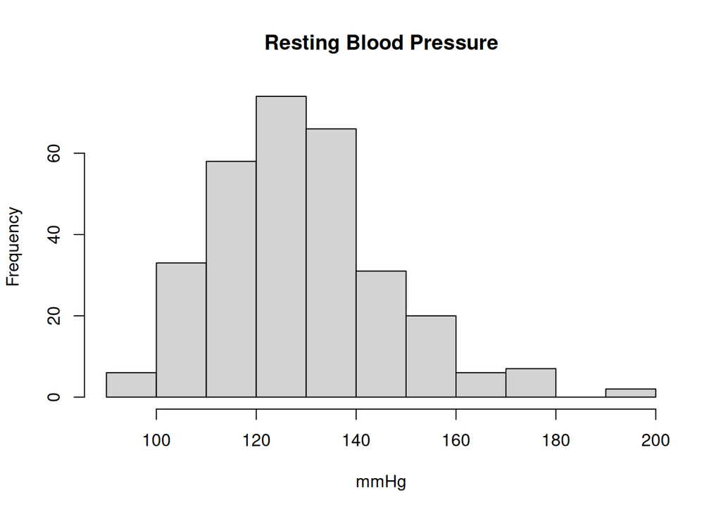

```r
hist(heart_disease_dataset$trestbps, main = "Resting Blood Pressure", xlab = "mmHg")
```

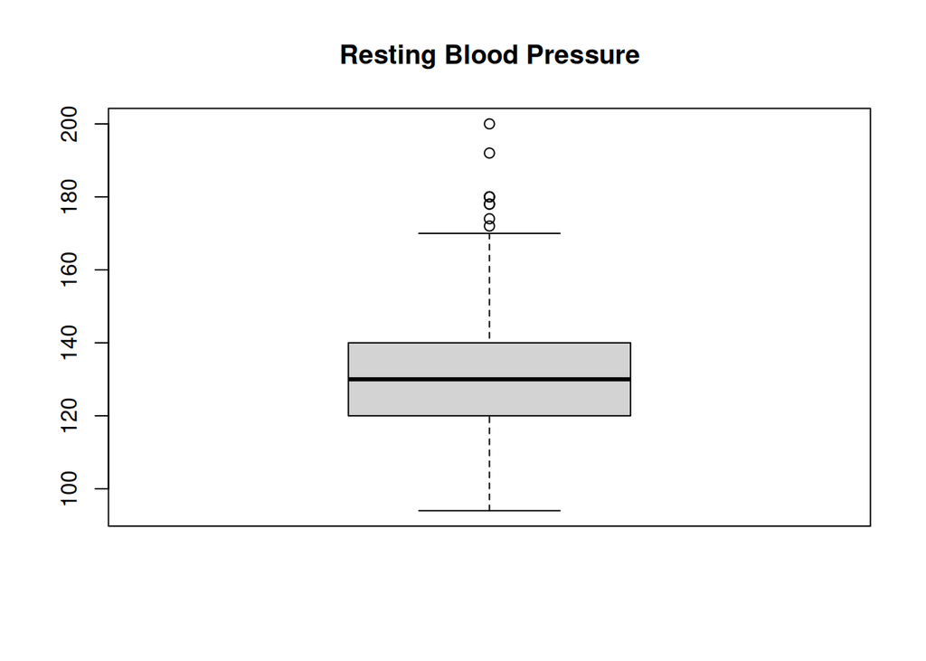

```r
boxplot(heart_disease_dataset$trestbps, main="Resting Blood Pressure")
```

This variable represents the blood pressure of the samples upon arrival at the hospital, measured in mmHg. There are no missing values; however, the box plot reveals the presence of outliers.

We decided to keep these outliers because, although a blood pressure of 200 mmHg is unusually elevated, it is possible. Additionally, since this data reflects the first measurement taken at the hospital, we cannot determine the condition of the patient when arrived.

### Analysis on Serum cholesterol (chol)

```r
# Checking for NAs
table(is.na(heart_disease_dataset$chol)) #No NA's found
```

```
##
## FALSE
##   303
```

```r
# Analysis on the variable
summary(heart_disease_dataset$chol)
```

```
##    Min. 1st Qu.  Median    Mean 3rd Qu.    Max.
##   126.0   211.0   241.0   246.7   275.0   564.0
```

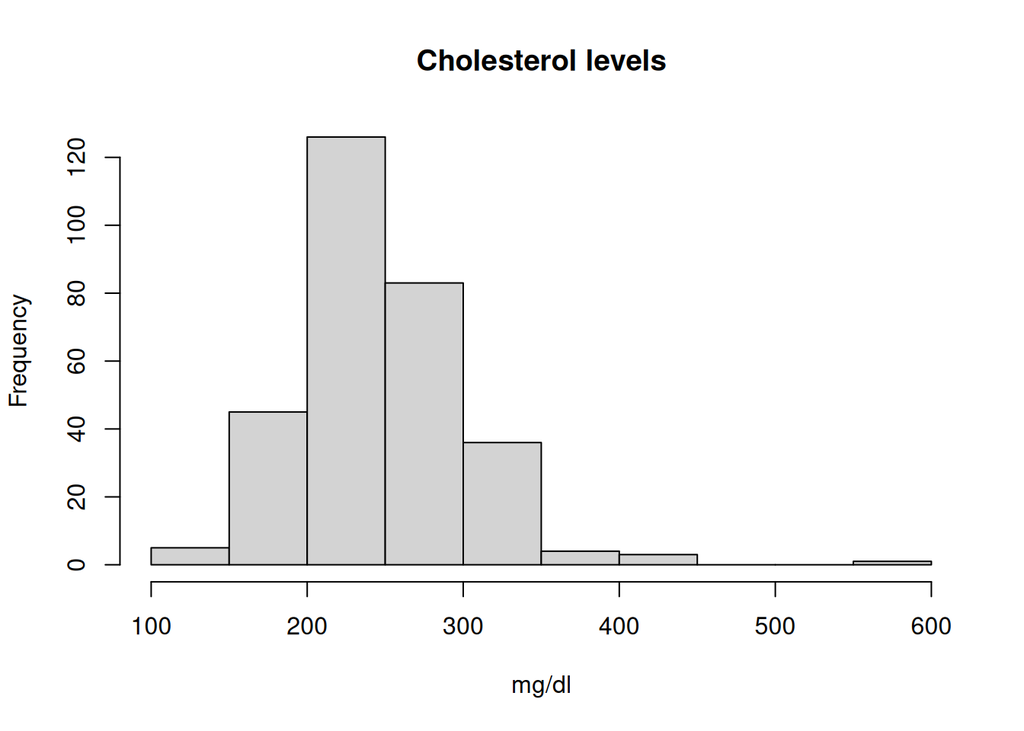

```r
hist(heart_disease_dataset$chol, main = "Cholesterol levels", xlab = "mg/dl")
```

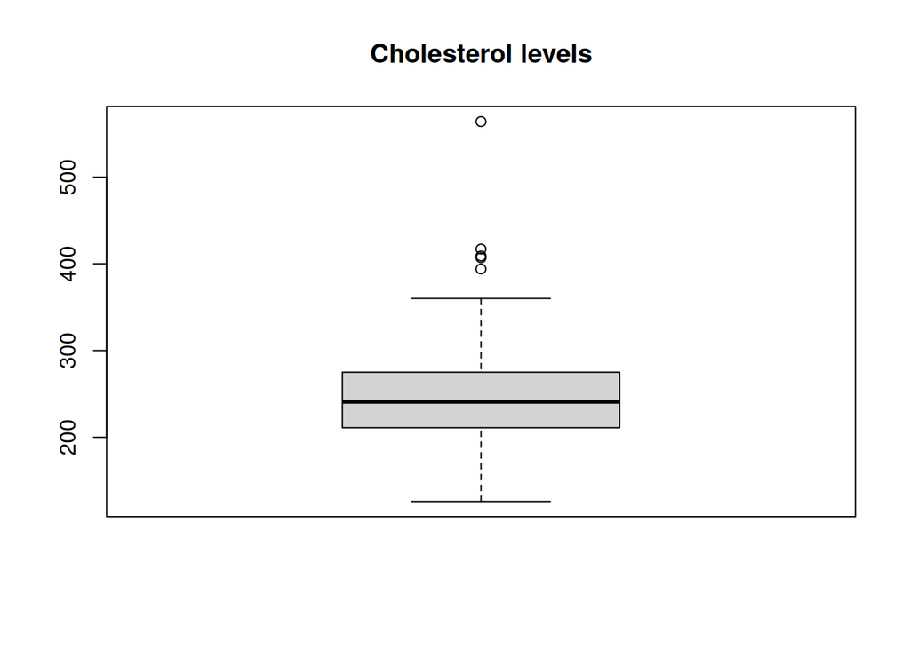

```r
boxplot(heart_disease_dataset$chol, main="Cholesterol levels")
```

```r
# Removing outliers
outliers_column<- (heart_disease_dataset$chol>=371)
table(outliers_column) #with 371 as a threshold we have 5 outliers
```

```
## outliers_column
## FALSE  TRUE
##   298     5
```

```r
# Making a subset of our data to analyse cholesterol
data_chol <- subset(heart_disease_dataset, heart_disease_dataset$chol <= 371)
#performing the analysis for the new dataset which now has 298 observations
table(is.na(data_chol$chol))
```

```
##
## FALSE
##   298
```

```r
summary(data_chol$chol)
```

```
##    Min. 1st Qu.  Median    Mean 3rd Qu.    Max.
##   126.0   211.0   240.0   243.5   273.8   360.0
```

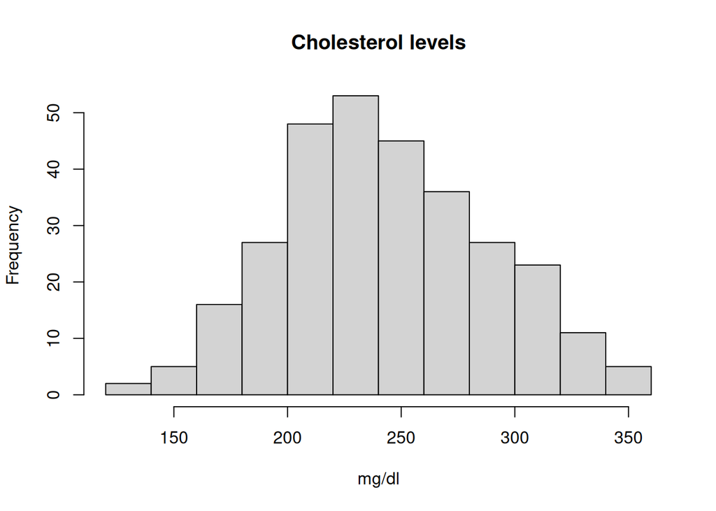

```r
hist(data_chol$chol, main = "Cholesterol levels", xlab = "mg/dl")
```

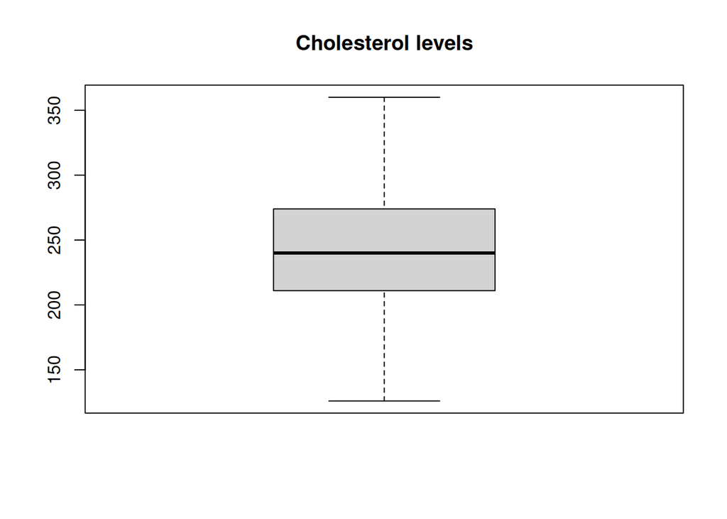

```r
boxplot(data_chol$chol, main="Cholesterol levels")
```

This variable represents the serum cholesterol level of the individuals measured in mg/dl. There are no missing values; however, the box plot reveals the presence of outliers.

In this case we have some non-realistic values. In order to determine a limit for outliers, to see what outliers should be deleted and which ones we although unusual should keep, we set the limit performing the next calculation: Quartile 3 + 1.5 x Interquartilic rank. Which gives a threshold of 371. Setting this limit, 5 observations were deleted. After this, we performed again the analysis. For further comparisons with this data set it should be taken into account we should use the “data_chol” data set created.

### Analysis on Fasting Blood Sugar (fbs)

If the fasting blood sugar is higher than 120 mg/dl the value will be 1, if not it will be 0.

```r
heart_disease_dataset$fbs <- factor(heart_disease_dataset$fbs,
                       levels = c(1, 0),
                       labels = c("High", "Low"))
table(heart_disease_dataset$fbs, useNA = "ifany")
```

```
##
## High  Low
##   45  258
```

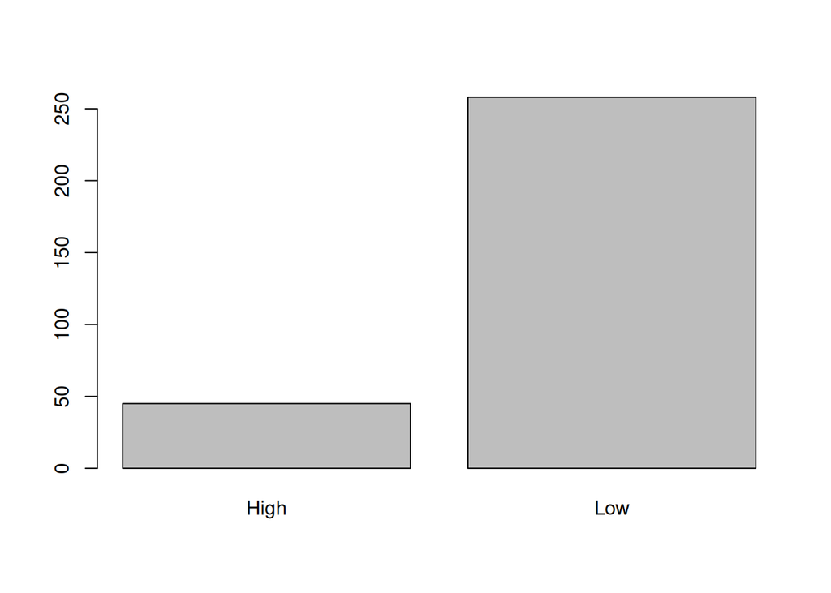

```r
barplot(table(heart_disease_dataset$fbs, useNA = "ifany"))
```

In this variable we can see we are not missing any data. We have two groups with very un-even sizes, having only 45 observations of high fasting blood sugar (>120 mg/dl) and 258 for low fasting blood sugar (<120 mg/dl).

### Analysis on Resting Electrocardiographic Results (restecg)

- Value 0: normal
- Value 1: having ST-T wave abnormality (T wave inversions and/or ST elevation or depression of > 0.05 mV)
- Value 2: showing probable or definite left ventricular hypertrophy by Estes’ criteria

```r
heart_disease_dataset$restecg <- factor(heart_disease_dataset$restecg,
                                        levels = c(0,1,2),
                                        labels = c("Normal", "ST-T wave abnormality", "Left ventricular hypertrophy"))
table(heart_disease_dataset$restecg, useNA = "ifany")
```

```
##
##                       Normal        ST-T wave abnormality
##                          151                            4
## Left ventricular hypertrophy
##                          148
```

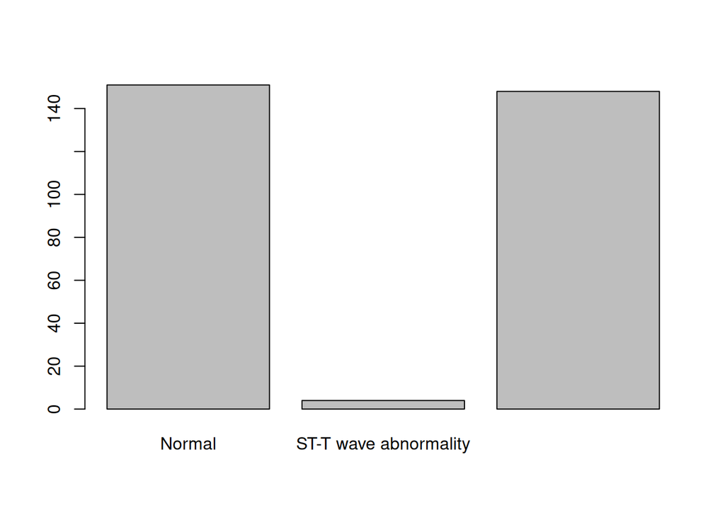

```r
barplot(table(heart_disease_dataset$restecg, useNA = "ifany"))
```

In this variable we have no missing data but again the groups show very different number of observations. In this case the group with ST-T wave abnormality is too small, only having 4 observations. In previous cases with un-leveled groups we did not make any changes because there were enough observations but in this case it is too low and 4 observations will not enable us to draw conclusions. For that reason we will create an other data set for further analysis without this 4 individuals.

```r
## Creating a subset without the ST-T wave abnormality subjects
    # value 1 corresponds to ST-T wave abnormality
data_restecg <- subset(heart_disease_dataset, heart_disease_dataset$restecg != "ST-T wave abnormality")
# Dropping unused factor levels
data_restecg$restecg <- droplevels(data_restecg$restecg)
# Analysis with the reduced dataset
table(data_restecg$restecg, useNA = "ifany")
```

```
##
##                       Normal Left ventricular hypertrophy
##                          151                          148
```

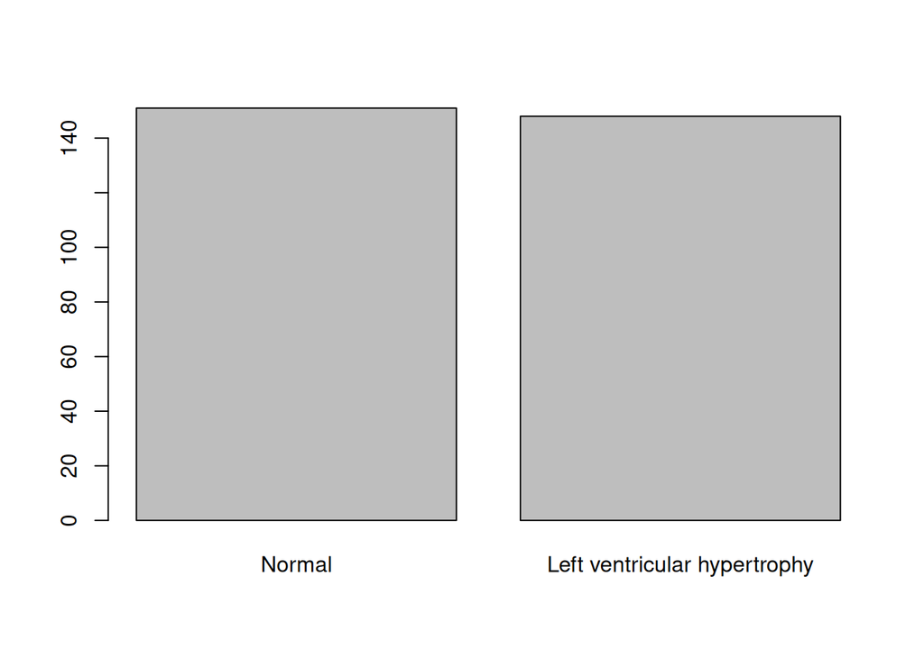

```r
barplot(table(data_restecg$restecg, useNA = "ifany"))
```

### Analysis on Maximum Heart Rate Achieved (thalach)

```r
table(is.na(heart_disease_dataset$thalach))
```

```
##
## FALSE
##   303
```

```r
summary(heart_disease_dataset$thalach)
```

```
##    Min. 1st Qu.  Median    Mean 3rd Qu.    Max.
##    71.0   133.5   153.0   149.6   166.0   202.0
```

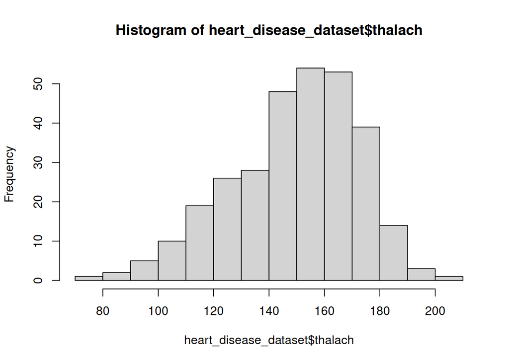

```r
hist(heart_disease_dataset$thalach)
```

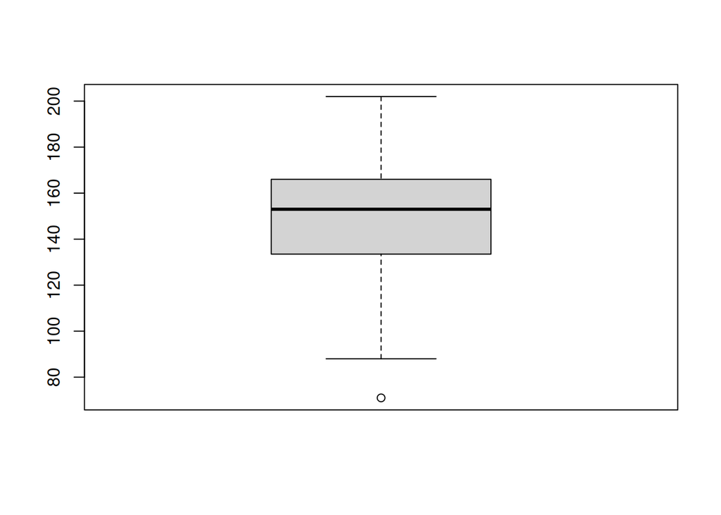

```r
boxplot(heart_disease_dataset$thalach)
```

In this analysis we can see what seems like an outlier. It is true that it could be a plaussible value for a heart rate but in rest, not for a maximum heart rate. Because of this, we though it may be an error in the dataset rather than a real extreme value. For that reason we again set a threshold regarding the interquartilic rank. Q1 -1.5 x IQR = 84.75. After that we created a new dataset to use in further analysis on Maximum heart Rate Achieved.

```r
# Making a subset of our data to analyse maximum heart rate achieved
data_thalach <- subset(heart_disease_dataset, heart_disease_dataset$thalach >= 84.75)
#performing the analysis for the new dataset which now has 302 observations
table(is.na(data_thalach$thalach))
```

```
##
## FALSE
##   302
```

```r
summary(data_thalach$thalach)
```

```
##    Min. 1st Qu.  Median    Mean 3rd Qu.    Max.
##    88.0   134.5   153.0   149.9   166.0   202.0
```

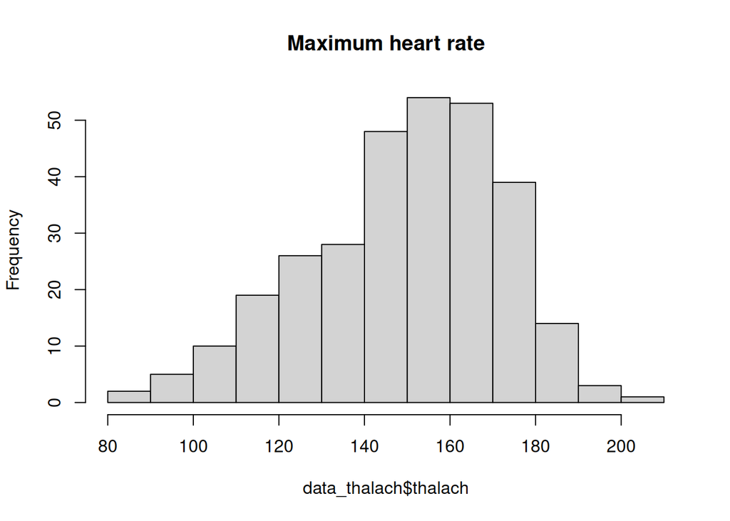

```r
hist(data_thalach$thalach, main = "Maximum heart rate")
```

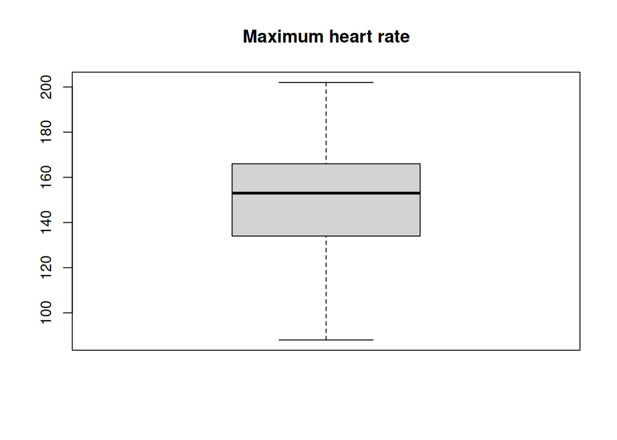

```r
boxplot(data_thalach$thalach, main="Maximum heart rate")
```

### Anaysis on exercise Induced Angina (exang)

The Exercise induced angina is categorized as 1 for yes and 0 for no.

```r
heart_disease_dataset$exang <- factor(heart_disease_dataset$exang,
                                        levels = c(0,1),
                                        labels = c("No", "Yes"))
table(heart_disease_dataset$exang, useNA = "ifany")
```

```
##
##  No Yes
## 204  99
```

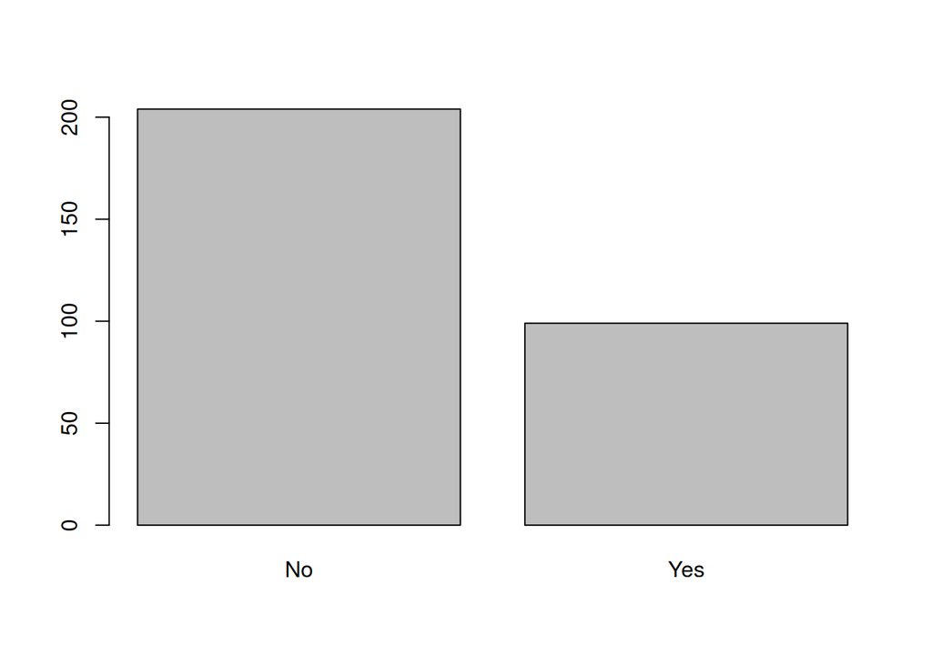

```r
barplot(table(heart_disease_dataset$exang, useNA = "ifany"))
```

In the analysis we can see how there is no missing data and we have to groups with different number of subjects.

### ST Depression Induced by Exercise Relative to Rest (oldpeak)

```r
table(is.na(heart_disease_dataset$oldpeak))
```

```
##
## FALSE
##   303
```

```r
summary(heart_disease_dataset$oldpeak)
```

```
##    Min. 1st Qu.  Median    Mean 3rd Qu.    Max.
##    0.00    0.00    0.80    1.04    1.60    6.20
```

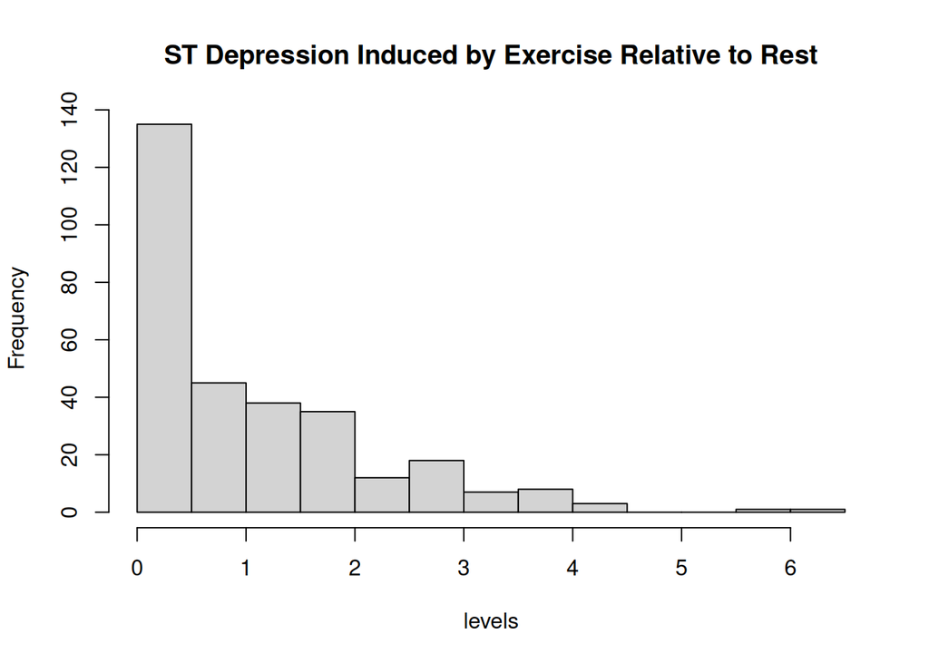

```r
hist(heart_disease_dataset$oldpeak, main = "ST Depression Induced by Exercise Relative to Rest", xlab="levels")
```

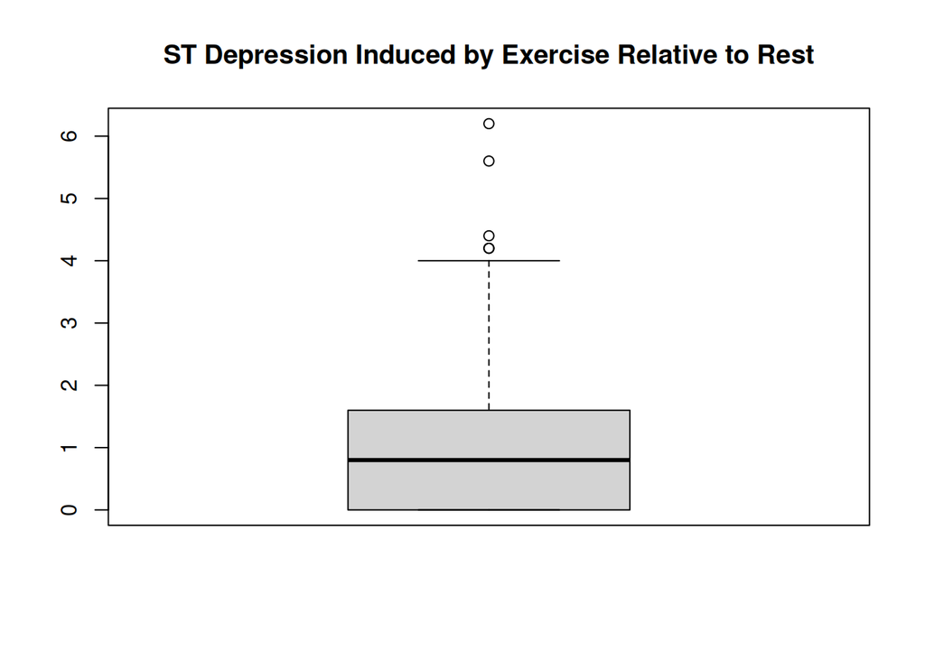

```r
boxplot(heart_disease_dataset$oldpeak, main="ST Depression Induced by Exercise Relative to Rest")
```

As there is no more description of this variable than the name, we are not able to decide whether the outliers are mistakes or could be real values. For that reason we decided to keep them but taking into account this fact.

### Analysis on slope of the Peak Exercise ST Segment (slope)

- Value 1: upsloping
- Value 2: flat
- Value 3: downsloping

```r
heart_disease_dataset$slope <- factor(heart_disease_dataset$slope,
                                        levels = c(1,2,3),
                                        labels = c("Upsloping", "Flat","Downsloping"))
table(heart_disease_dataset$slope, useNA = "ifany")
```

```
##
##   Upsloping        Flat Downsloping
##         142         140          21
```

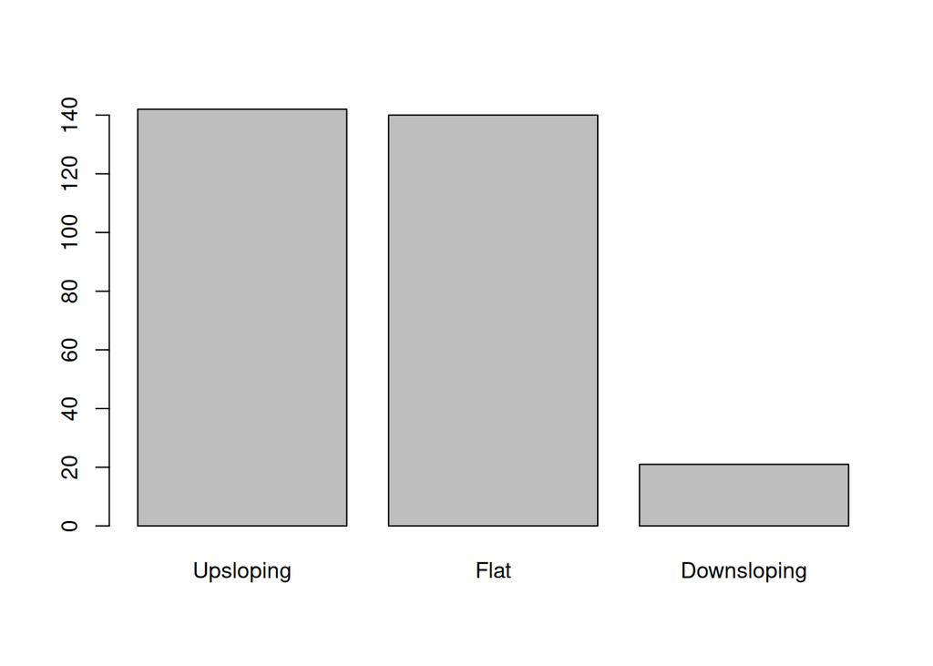

```r
barplot(table(heart_disease_dataset$slope, useNA = "ifany"))
```

After the analysis we can see there are three groups on this variable, with different number of subjects, being a big difference between “Upsloping” and “Flat” with “Downsloping”. As there are only 21 individuals in this last group, but we will keep the variable as it is as it has enough individuals to perform later on analysis.

### Analysis on number of major vessels colored by fluoroscopy (ca)

We have values only from 0 to 3. For that reason we will categorize it even though it has numerical values.

```r
heart_disease_dataset$ca <- factor(heart_disease_dataset$ca)
table(heart_disease_dataset$ca, useNA = "ifany")
```

```
##
##   ?   0   1   2   3
##   4 176  65  38  20
```

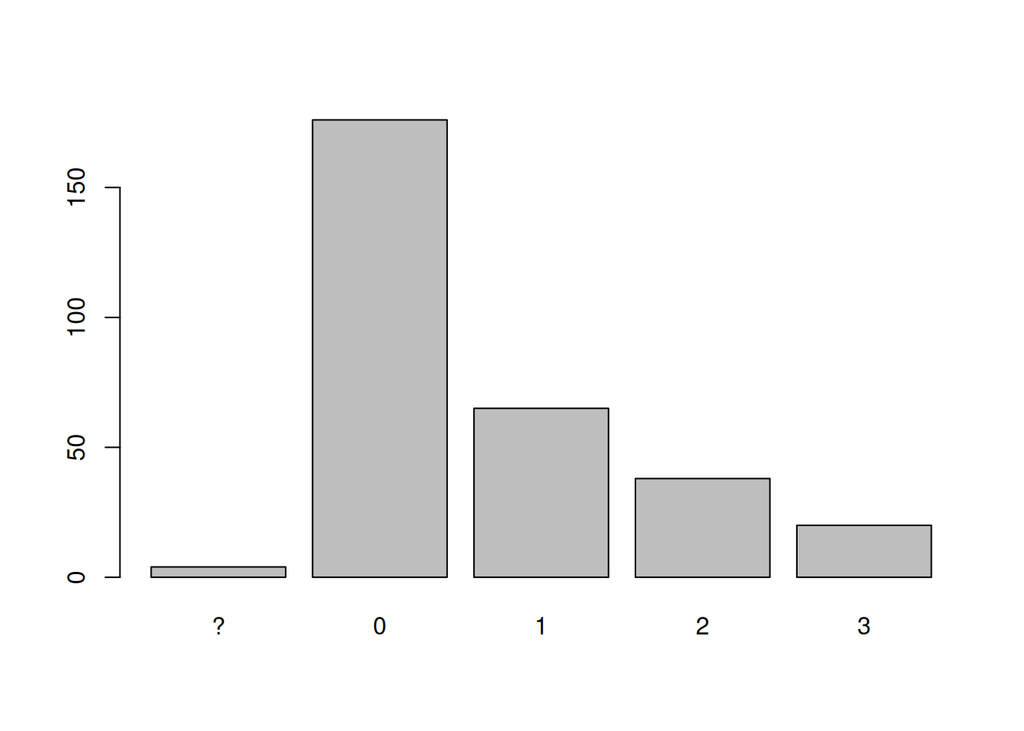

```r
barplot(table(heart_disease_dataset$ca, useNA = "ifany"))
```

In this preliminar analysis we can see that there are 4 individuals from which we do not the number of main vessels, for this reason we will create a subset without them.

```r
## Creating a subset without the ? subjects
data_ca <- subset(heart_disease_dataset, heart_disease_dataset$ca != "?")

#Performing the analysis with the reduced dataset
data_ca$ca <- factor(data_ca$ca)
table(data_ca$ca, useNA = "ifany")
```

```
##
##   0   1   2   3
## 176  65  38  20
```

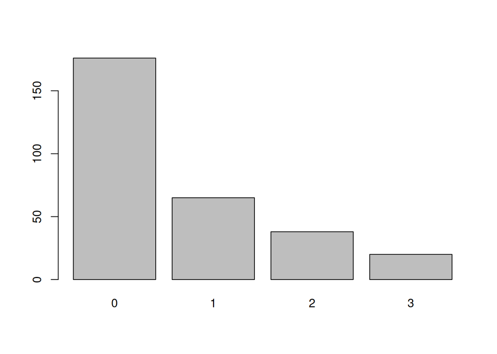

```r
barplot(table(data_ca$ca, useNA = "ifany"))
```

### Analysis on thalassemia (thal)

- 3 = normal
- 6 = fixed defect
- 7 = reversable defect

```r
heart_disease_dataset$thal <- factor(heart_disease_dataset$thal,
                                        levels = c(3,6,7),
                                        labels = c("Normal", "Fixed defect","Reversable defect"))
table(heart_disease_dataset$thal, useNA = "ifany")
```

```
##
##            Normal      Fixed defect Reversable defect              <NA>
##               166                18               117                 2
```

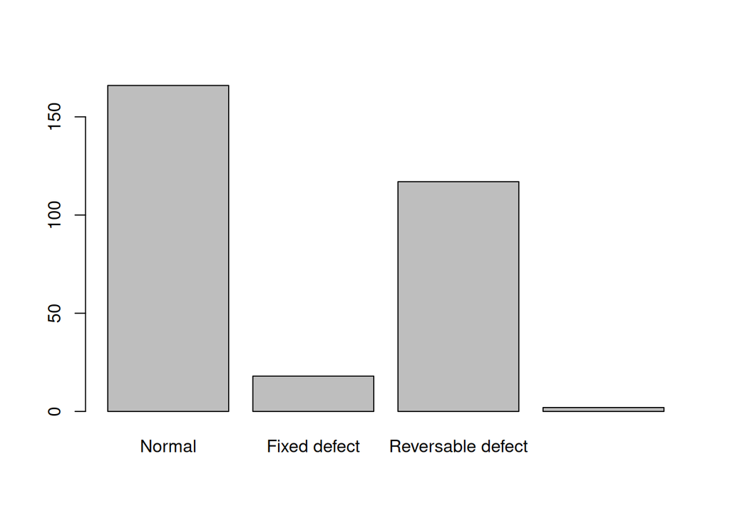

```r
barplot(table(heart_disease_dataset$thal, useNA = "ifany"))
```

There are 2 NA’s so we will create an other subset from the data to eliminate this individuals when performing an analysis with this variable.

```r
## Creating a subset without the NA's
data_thal <- subset(heart_disease_dataset, heart_disease_dataset$thal != "NA")

#Performing the analysis with the reduced dataset
data_thal$thal <- factor(data_thal$thal)
table(data_thal$thal, useNA = "ifany")
```

```
##
##            Normal      Fixed defect Reversable defect
##               166                18               117
```

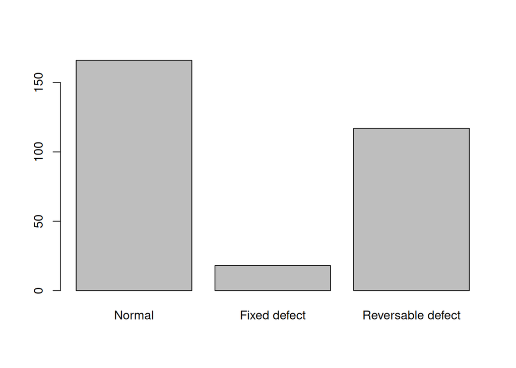

```r
barplot(table(data_thal$thal, useNA = "ifany"))
```

We can see three un-leveled groups, which makes sense as we would not expect many subjects with thalassemia.

## Create visualizations in order to show which variables seem to be more associated with heart disease

##### Age and Diagnosis of heart disease (num)

```r
# Descriptive analysis
by(heart_disease_dataset$age, heart_disease_dataset$num,summary)
```

```
## heart_disease_dataset$num: Absence
##    Min. 1st Qu.  Median    Mean 3rd Qu.    Max.
##   29.00   44.75   52.00   52.59   59.00   76.00
## ------------------------------------------------------------
## heart_disease_dataset$num: Presence
##    Min. 1st Qu.  Median    Mean 3rd Qu.    Max.
##   35.00   52.00   58.00   56.63   62.00   77.00
```

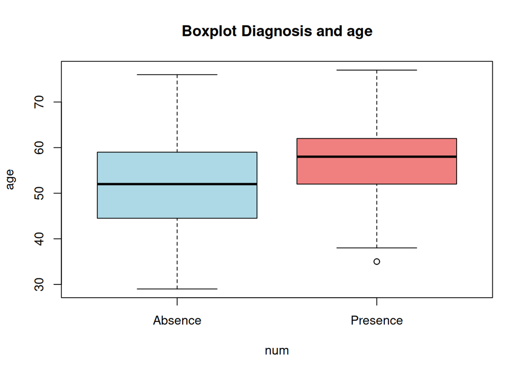

```r
boxplot(age ~ num,
        heart_disease_dataset, main='Boxplot Diagnosis and age',col=c('lightblue','lightcoral'))
```

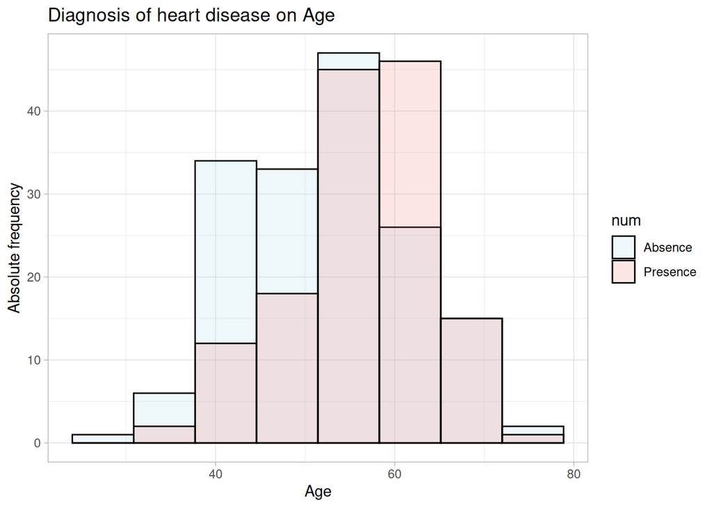

```r
ggplot(data = heart_disease_dataset, aes(x = age, fill = num)) +
  geom_histogram(alpha = .2, position = "identity", color = "black", bins = 8) + labs(x = "Age", y = "Absolute frequency", title = "Diagnosis of heart disease on Age") +
  scale_fill_manual(values = c('lightblue', 'lightcoral')) +
  theme_light()
```

```r
## T-test
#Checking normal distribution of the data
shapiro.test(heart_disease_dataset$age[heart_disease_dataset$num=="Absence"]) #Follows a normal distribution
```

```
##
##  Shapiro-Wilk normality test
##
## data:  heart_disease_dataset$age[heart_disease_dataset$num == "Absence"]
## W = 0.987, p-value = 0.132
```

```r
shapiro.test(heart_disease_dataset$age[heart_disease_dataset$num=="Presence"]) # Does not follow a normal distribution
```

```
##
##  Shapiro-Wilk normality test
##
## data:  heart_disease_dataset$age[heart_disease_dataset$num == "Presence"]
## W = 0.96774, p-value = 0.002256
```

```r
#Checking the variance
var.test(age~num,data=heart_disease_dataset) #no homogeneity of variances
```

```
##
##  F test to compare two variances
##
## data:  age by num
## F = 1.4357, num df = 163, denom df = 138, p-value = 0.02883
## alternative hypothesis: true ratio of variances is not equal to 1
## 95 percent confidence interval:
##  1.038341 1.976569
## sample estimates:
## ratio of variances
##           1.435728
```

```r
t.test(age~num,data=heart_disease_dataset,var.equal = FALSE) #there is statistical difference
```

```
##
##  Welch Two Sample t-test
##
## data:  age by num
## t = -4.0303, df = 300.93, p-value = 7.061e-05
## alternative hypothesis: true difference in means between group Absence and group Presence is not equal to 0
## 95 percent confidence interval:
##  -6.013385 -2.067682
## sample estimates:
##  mean in group Absence mean in group Presence
##               52.58537               56.62590
```

From the T-test we can see there are statistical differences in age between both groups.

##### Sex and Diagnosis of heart disease (num)

```r
# Absolute Frequences
sex_Diagnosis_table<-table(heart_disease_dataset$num, heart_disease_dataset$sex)
(sex_Diagnosis_table_total <- addmargins(sex_Diagnosis_table))
```

```
##
##            Male Female Sum
##   Absence    92     72 164
##   Presence  114     25 139
##   Sum       206     97 303
```

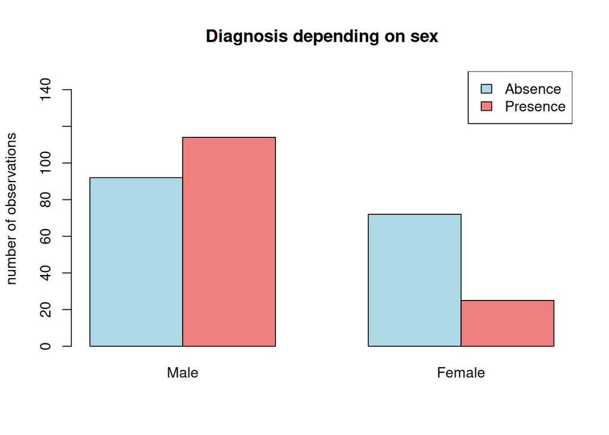

```r
barplot(sex_Diagnosis_table,
        col = c('lightblue', 'lightcoral'),
        beside = TRUE,
        ylim = c(0, 150), ylab = "number of observations", main = "Diagnosis depending on sex");legend(x = "topright",legend = unique(heart_disease_dataset$num),  fill = c('lightblue', 'lightcoral'))
```

```r
#Relative Frequences tables
(sex_Diagnosis_table_freqs <- prop.table(sex_Diagnosis_table))
```

```
##
##                  Male     Female
##   Absence  0.30363036 0.23762376
##   Presence 0.37623762 0.08250825
```

```r
(sex_Diagnosis_table_freqs_total <- addmargins(sex_Diagnosis_table_freqs))
```

```
##
##                  Male     Female        Sum
##   Absence  0.30363036 0.23762376 0.54125413
##   Presence 0.37623762 0.08250825 0.45874587
##   Sum      0.67986799 0.32013201 1.00000000
```

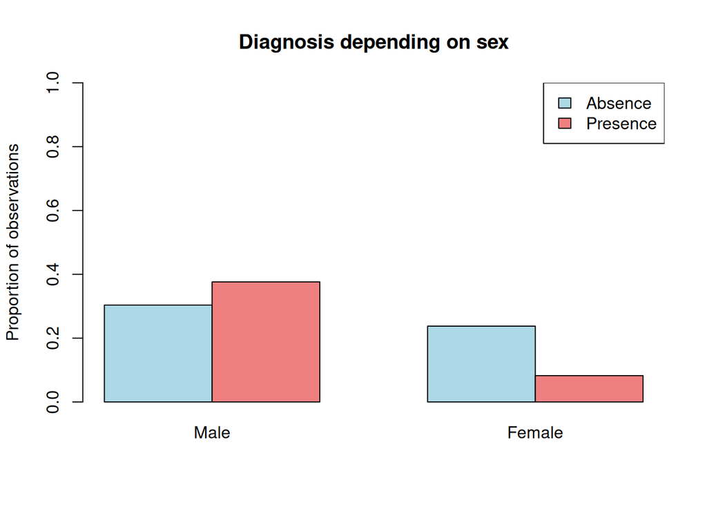

```r
barplot(sex_Diagnosis_table_freqs,
        col = c('lightblue', 'lightcoral'),
        beside = TRUE,
        ylim = c(0, 1), ylab = "Proportion of observations", main = "Diagnosis depending on sex");legend(x = "topright",legend = unique(heart_disease_dataset$num),  fill = c('lightblue', 'lightcoral'))
```

```r
#Fisher test
fisher.test(sex_Diagnosis_table, alternative = "two.sided") #Significative
```

```
##
##  Fisher's Exact Test for Count Data
##
## data:  sex_Diagnosis_table
## p-value = 1.259e-06
## alternative hypothesis: true odds ratio is not equal to 1
## 95 percent confidence interval:
##  0.1577210 0.4902102
## sample estimates:
## odds ratio
##  0.2814093
```

```r
assocstats(sex_Diagnosis_table)
```

```
##                     X^2 df   P(> X^2)
## Likelihood Ratio 24.049  1 9.3901e-07
## Pearson          23.218  1 1.4463e-06
##
## Phi-Coefficient   : 0.277
## Contingency Coeff.: 0.267
## Cramer's V        : 0.277
```

From the descriptive we could already see like it seemed to be some differences and this is confirmed by the Fisher test and the other parameters produced by the function assocstats.

##### Chest pain (cp) and Diagnosis of heart disease (num)

```r
# Absolute Frequences
cp_Diagnosis_table<-table(heart_disease_dataset$num, heart_disease_dataset$cp)
(cp_Diagnosis_table_total <- addmargins(cp_Diagnosis_table))
```

```
##
##            Typical Angina Atypical Angina Non-Anginal Pain Asymptomatic Sum
##   Absence              16              41               68           39 164
##   Presence              7               9               18          105 139
##   Sum                  23              50               86          144 303
```

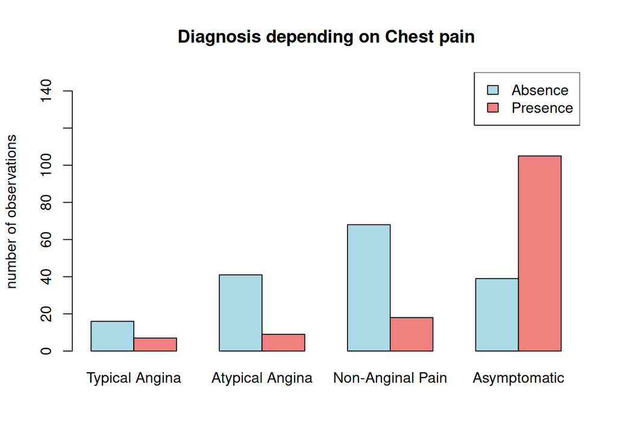

```r
barplot(cp_Diagnosis_table,
        col = c('lightblue', 'lightcoral'),
        beside = TRUE,
        ylim = c(0, 150), ylab = "number of observations", main = "Diagnosis depending on Chest pain");legend(x = "topright",legend = unique(heart_disease_dataset$num),  fill = c('lightblue', 'lightcoral'))
```

```r
#Relative Frequences tables
(cp_Diagnosis_table_freqs <- prop.table(cp_Diagnosis_table))
```

```
##
##            Typical Angina Atypical Angina Non-Anginal Pain Asymptomatic
##   Absence      0.05280528      0.13531353       0.22442244   0.12871287
##   Presence     0.02310231      0.02970297       0.05940594   0.34653465
```

```r
(cp_Diagnosis_table_freqs_total <- addmargins(cp_Diagnosis_table_freqs))
```

```
##
##            Typical Angina Atypical Angina Non-Anginal Pain Asymptomatic
##   Absence      0.05280528      0.13531353       0.22442244   0.12871287
##   Presence     0.02310231      0.02970297       0.05940594   0.34653465
##   Sum          0.07590759      0.16501650       0.28382838   0.47524752
##
##                   Sum
##   Absence  0.54125413
##   Presence 0.45874587
##   Sum      1.00000000
```

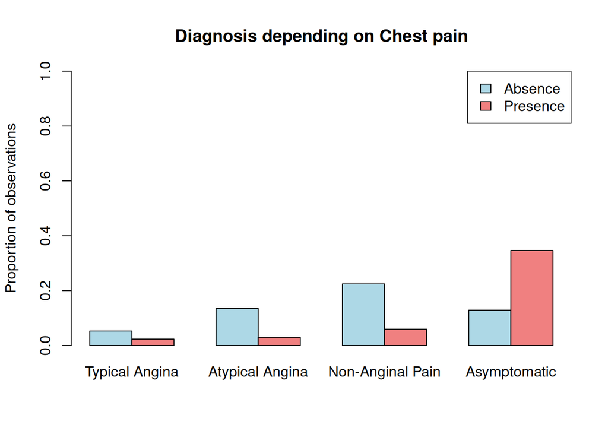

```r
barplot(cp_Diagnosis_table_freqs,
        col = c('lightblue', 'lightcoral'),
        beside = TRUE,
        ylim = c(0, 1), ylab = "Proportion of observations", main = "Diagnosis depending on Chest pain");legend(x = "topright",legend = unique(heart_disease_dataset$num),  fill = c('lightblue', 'lightcoral'))
```

```r
#Fisher test
fisher.test(cp_Diagnosis_table, alternative = "two.sided") #significative
```

```
##
##  Fisher's Exact Test for Count Data
##
## data:  cp_Diagnosis_table
## p-value < 2.2e-16
## alternative hypothesis: two.sided
```

```r
assocstats(cp_Diagnosis_table)
```

```
##                     X^2 df P(> X^2)
## Likelihood Ratio 86.118  3        0
## Pearson          81.816  3        0
##
## Phi-Coefficient   : NA
## Contingency Coeff.: 0.461
## Cramer's V        : 0.52
```

```r
#Chi-squared test
res<-chisq.test(cp_Diagnosis_table)
res
```

```
##
##  Pearson's Chi-squared test
##
## data:  cp_Diagnosis_table
## X-squared = 81.816, df = 3, p-value < 2.2e-16
```

```r
res$observed
```

```
##
##            Typical Angina Atypical Angina Non-Anginal Pain Asymptomatic
##   Absence              16              41               68           39
##   Presence              7               9               18          105
```

```r
res$expected
```

```
##
##            Typical Angina Atypical Angina Non-Anginal Pain Asymptomatic
##   Absence        12.44884        27.06271         46.54785     77.94059
##   Presence       10.55116        22.93729         39.45215     66.05941
```

```r
res$residuals
```

```
##
##            Typical Angina Atypical Angina Non-Anginal Pain Asymptomatic
##   Absence        1.006480        2.679124         3.144278    -4.410834
##   Presence      -1.093250       -2.910096        -3.415352     4.791100
```

As we see in the Chi-squared test, there are significant differences between groups of chest pain according to the diagnosis. Also looking at the residuals we can see that the asymptomatic group is the one which contributes the most to this chi-squared results.